# jekyll-jupyter-notebook20240415-1921-74bz07

## 1 Membaca Data

`obspy` dapat membaca berbagai jenis format data ataupun metadata, untuk membaca data kita dapat menggunakan fungsi `read`:

```python
from obspy import read

st=read('/content/drive/MyDrive/BMKG_Akselerometer/event-sundastrait-20210321/ASJR_E.mseed')
print(st)
```

```
1 Trace(s) in Stream:
IA.ASJR.00.HNE | 2021-03-21T05:56:43.000000Z - 2021-03-21T06:31:43.000000Z | 100.0 Hz, 210001 samples
```

Data rekaman yang dibaca `obspy` akan disimpan dalam bentuk objek `Stream` di memori, struktur objek ini adalah seperti pada gambar di bawah ini:

[figure not shown]

Pada contoh di atas tertulis bahwa terdapat 1 `Trace` dalam `Stream`, `Trace` merupakan objek data 1 komponen sedangkan `Stream` merupakan object data 1 stasiun sehingga 1 `Stream` bisa terdiri atas banyak `Trace`. Data yang sudah terbaca terdiri atas 1 komponen saja. Kita dapat mengeplot data menggunakan:

```python
st.plot()
```

[output not shown]

Dalam object `Stream` informasi mengenai parameter rekaman seperti `sampling_rate` dan yang lain tersimpan dalam masing-masing `Trace`. `Trace` dapat diambil dengan menggunakan indeks:

```python
tr1 = st[0] #index 0 untuk Trace pertama
tr1.plot()
```

[output not shown]

Informasi parameter perekaman dapat diakses menggunakan `Trace.stats`:

```python
tr1.stats
```

```
         network: IA
         station: ASJR
        location: 00
         channel: HNE
       starttime: 2021-03-21T05:56:43.000000Z
         endtime: 2021-03-21T06:31:43.000000Z
   sampling_rate: 100.0
           delta: 0.01
            npts: 210001
           calib: 1.0
         _format: MSEED
           mseed: AttribDict({'dataquality': 'R', 'number_of_records': 517, 'encoding': 'STEIM1', 'byteorder': '>', 'record_length': 512, 'filesize': 264704})
```

## 2 Menggabungkan Data

Data dalam setiap komponen E, N, dan Z dapat digabungkan dalam 1 `Stream` sehingga nantinya 1 `Stream` terdiri atas 3 `Trace`:

```python
st=read('/content/drive/MyDrive/BMKG_Akselerometer/event-sundastrait-20210321/ASJR_Z.mseed')
st+=read('/content/drive/MyDrive/BMKG_Akselerometer/event-sundastrait-20210321/ASJR_N.mseed')
st+=read('/content/drive/MyDrive/BMKG_Akselerometer/event-sundastrait-20210321/ASJR_E.mseed')
print(st)
```

```
3 Trace(s) in Stream:
IA.ASJR.00.HNZ | 2021-03-21T05:56:43.000000Z - 2021-03-21T06:31:43.000000Z | 100.0 Hz, 210001 samples
IA.ASJR.00.HNN | 2021-03-21T05:56:43.000000Z - 2021-03-21T06:31:43.000000Z | 100.0 Hz, 210001 samples
IA.ASJR.00.HNE | 2021-03-21T05:56:43.000000Z - 2021-03-21T06:31:43.000000Z | 100.0 Hz, 210001 samples
```

Dari hasil menjalankan perintah di atas kita mendapatkan 1 `Stream` dengan 3 komponen (`Trace`).

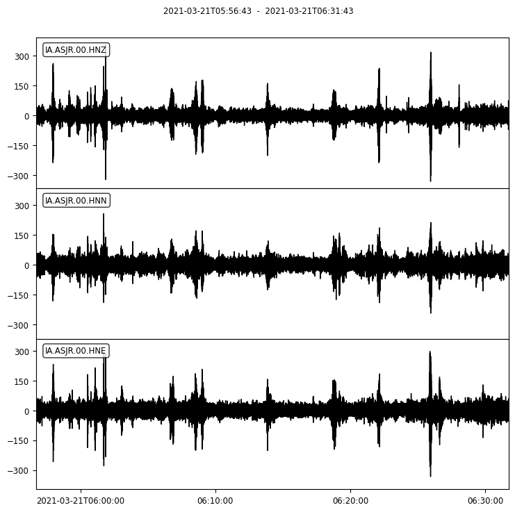

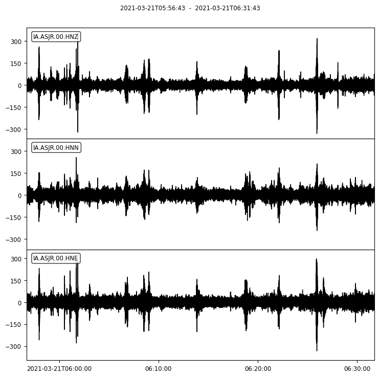

```python
st.plot()
```

```python
tr2 = st[0]
print(tr2.stats)
```

```
         network: IA
         station: ASJR
        location: 00
         channel: HNZ
       starttime: 2021-03-21T05:56:43.000000Z
         endtime: 2021-03-21T06:31:43.000000Z
   sampling_rate: 100.0
           delta: 0.01
            npts: 210001
           calib: 1.0
         _format: MSEED
           mseed: AttribDict({'dataquality': 'R', 'number_of_records': 515, 'encoding': 'STEIM1', 'byteorder': '>', 'record_length': 512, 'filesize': 263680})
```

Jika informasi parameter rekaman dapat diambil dari `Trace.stats` maka informasi yang berisi data rekaman dapat diakses dengan `Trace.data`:

```python
tr2.data
```

```
array([ 3, 12,  0, ...,  0, 13,  3], dtype=int32)
```

Sehingga bisa kita plot data dengan cara yang lain misalkan dengan bantuan `matplotlib`:

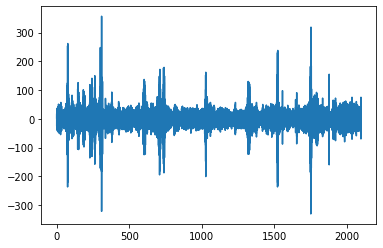

```python
import matplotlib.pyplot as plt

data = tr2.data
waktu = tr2.times()

plt.plot(waktu, data)
```

## 3 Melakukan pengolahan sinyal sederhana

`obspy` sudah melengkapi `Stream` dengan berbagai fungsi untuk memodifikasi data, kita dapat melihat fungsi (`method`) apa saja yang didukung oleh `obspy` dalam `Stream` dengan:

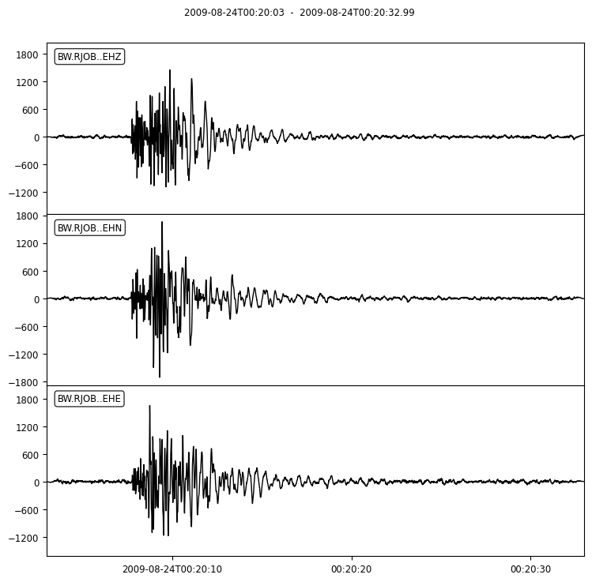

[output not shown]

[output cut: 1562 more lines]

[output not shown]

```python
from obspy import read
st = read()
st.filter("highpass",freq=1.0)
st.plot()
help(st)
```